# Get Started

Maciej Nasinski

2024-01-22

## `cat2cat` procedure

The introduced `cat2cat` procedure was designed to offer an easy and clear interface to apply a mapping (transition) table which was provided by the data maintainer or built by a researcher. The objective is to unify an inconsistent coded categorical variable in a panel dataset, where a transition table is the core element of the process.

Examples of datasets with such inconsistent coded categorical variable are ISCO (The International Standard Classification of Occupations) or ICD (International Classification of Diseases) based one. The both classifications are regularly updated to adjust to e.g. new science achievements. More clearly we might image that e.g. new science achievements brings new occupations types on the market or enable recognition of new diseases types.

The categorical variable encoding changes are typically provided by datasets providers in the mapping (transition) table form, for each time point the changes occurred. The mapping (transition) table is the core element of the procedure A mapping table conveys information needed for matching all categories between two periods of time. More precisely it contains two columns where the first column contains old categories and the second column contains the new ones. Sometimes a mapping (transition) table has to be created manually by a researcher.

The main rule is to replicate the observation if it could be assigned to a few categories. More precisely for each observation we look across a mapping (transition) table to check how the original category could be mapped to the opposite period one. Then using simple frequencies or statistical methods to approximate weights (probabilities) of being assigned to each of them. For each observation that was replicated, the probabilities have to add up to one. The algorithm distinguishes different mechanics for panel data with and without unique identifiers.

## cat2cat function

The `cat2cat::cat2cat` function is the implementation of the `cat2cat` procedure. The `cat2cat::cat2cat` function has three arguments `data`, `mappings`, and `ml`. Each of these arguments is of a `list` type, wherein the `ml` argument is optional. Arguments are separated to identify the core elements of the `cat2cat` procedure. Although this function seems complex initially, it is built to offer a wide range of applications for complex tasks. The function contains many validation checks to prevent incorrect usage. The function has to be applied iteratively for each two neighboring periods of a panel dataset. The `cat2cat::prune_c2c` function could be needed to limit growing number of replications.

## Core elements

There are 3 important elements:

1. Mapping (Transition) table, possibly a few for longer panels. Typically provided by the data maintainers like a statistical office.
2. Type of the data - panel dataset with unique identifiers vs panel dataset without unique identifiers and aggregate data vs non-aggragate data.
3. Direction of a mapping process, forward or backward - a new or an old encoding as a base one.

## Data

`occup` dataset is an example of unbalance panel dataset. This is a simulated data although there are applied a real world characteristics from national statistical office survey. The original survey is anonymous and take place **every two years**.

`trans` mapping (transition) table contains mappings between old (2008) and new (2010) occupational codes. This table could be used to map encodings in both directions.

```r
library("cat2cat")
library("dplyr")

data("occup", package = "cat2cat")
data("trans", package = "cat2cat")

occup_2006 <- occup[occup$year == 2006, ]
occup_2008 <- occup_old <- occup[occup$year == 2008, ]
occup_2010 <- occup_new <- occup[occup$year == 2010, ]
occup_2012 <- occup[occup$year == 2012, ]
```

## Dataset without unique identifiers

There were prepared two graphs for forward and backward mapping. These graphs present how the `cat2cat::cat2cat` procedure works, in this case under a panel dataset without the unique identifiers and only two periods.

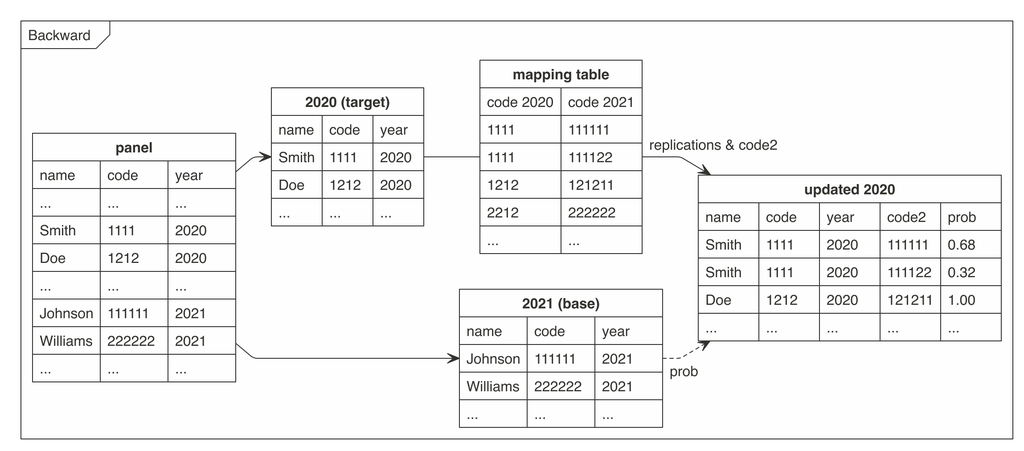

Backward Mapping

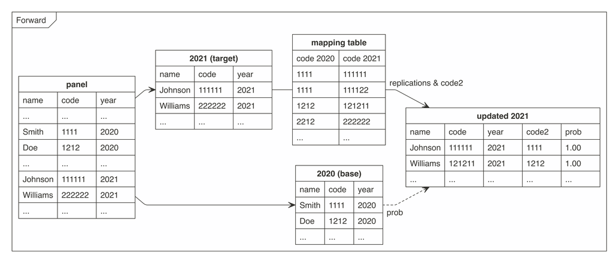

Forward Mapping

### Example - 2 periods

```r
## cat2cat
occup_simple <- cat2cat(
  data = list(
    old = occup_old, new = occup_new, cat_var = "code", time_var = "year"
  ),
  mappings = list(trans = trans, direction = "backward")
)

## with informative features it might be usefull to run ml algorithm
## currently knn, lda and rf (randomForest), could be a few at once
## where probability will be assessed as fraction of closest points.
occup_2 <- cat2cat(
  data = list(
    old = occup_old, new = occup_new,
    cat_var = "code", time_var = "year"
  ),
  mappings = list(trans = trans, direction = "backward"),
  ml = list(
    data = occup_new,
    cat_var = "code",
    method = "knn",
    features = c("age", "sex", "edu", "exp", "parttime", "salary"),
    args = list(k = 10)
  )
)
```

`plot_c2c` offers a summary of the replication process.

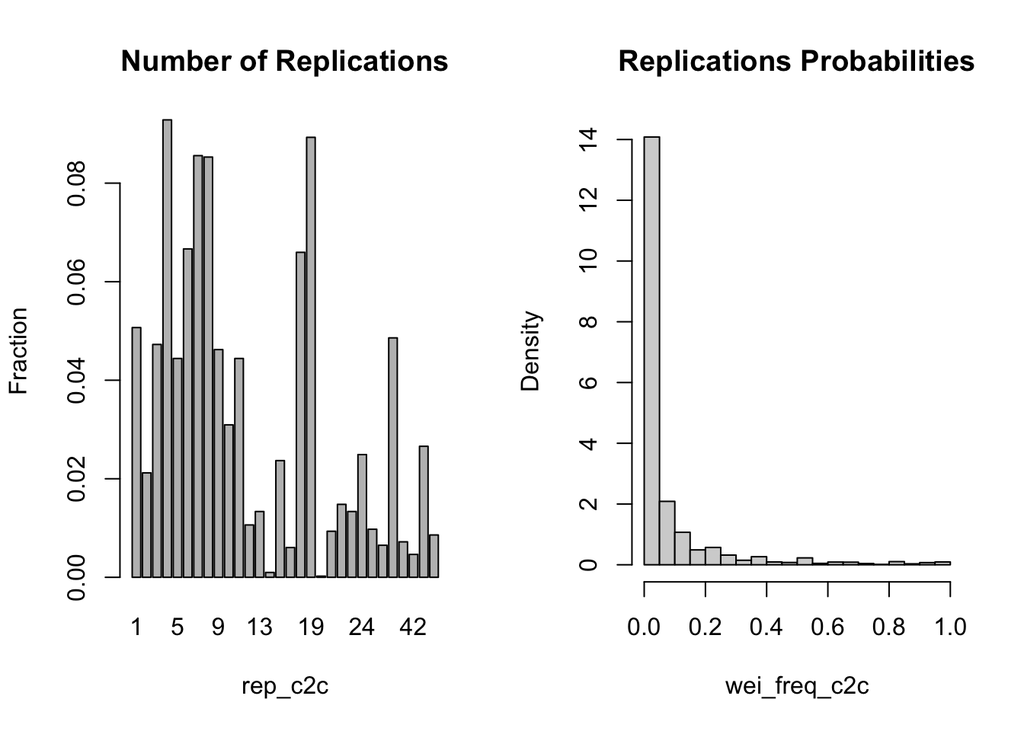

```r
# summary_plot
plot_c2c(occup_2$old, type = c("both"))
```

Example for the 2 period panel dataset.

```r
# mix of methods
occup_2_mix <- cat2cat(
  data = list(
    old = occup_old, new = occup_new,
    cat_var = "code", time_var = "year"
  ),
  mappings = list(trans = trans, direction = "backward"),
  ml = list(
    data = occup_new,
    cat_var = "code",
    method = c("knn", "rf", "lda"),
    features = c("age", "sex", "edu", "exp", "parttime", "salary"),
    args = list(k = 10, ntree = 50)
  )
)
# cross all methods and subset one highest probability category for each subject
occup_old_mix_highest1 <- occup_2_mix$old %>%
  cross_c2c(.) %>%
  prune_c2c(., column = "wei_cross_c2c", method = "highest1")
```

Correlations between different methods of assesing weights are presented.

```r
# correlation between ml models and simple fequencies
occup_2_mix$old %>%
  select(wei_knn_c2c, wei_rf_c2c, wei_lda_c2c, wei_freq_c2c) %>%
  cor()
```

```
##              wei_knn_c2c wei_rf_c2c wei_lda_c2c wei_freq_c2c
## wei_knn_c2c    1.0000000  0.8640326   0.8350984    0.8989887
## wei_rf_c2c     0.8640326  1.0000000   0.8792346    0.8755379
## wei_lda_c2c    0.8350984  0.8792346   1.0000000    0.8807702
## wei_freq_c2c   0.8989887  0.8755379   0.8807702    1.0000000
```

### Example - More than 2 periods

When we have to map more than 2 time points, then cat2cat has to be used iteratively. However when only three periods have to be mapped, the middle one could be used as the base one.  
If we have to apply many different mapping (transition) tables over time then pruning methods could be needed to limit the exponentially growing number of replications. Such pruning methods are used to remove some of the replications, for example, leaving only one observation with the highest probability for each observation replication. Another strategy might be removing the zero probability replications. As such, pruning methods could be used before transferring a dataset to the next iteration to reduce the problem of the exponentially growing number of observations.

Example with 4 period and only one mapping table:

#### Backward

Unification Process:

```r
# from 2010 to 2008
occup_back_2008_2010 <- cat2cat(
  data = list(
    old = occup_2008, new = occup_2010,
    cat_var = "code", time_var = "year"
  ),
  mappings = list(trans = trans, direction = "backward")
)

# optional, give more control
# the counts could be any of wei_* or their combination
freqs_df <-
  occup_back_2008_2010$old[, c("g_new_c2c", "wei_freq_c2c")] %>%
  group_by(g_new_c2c) %>%
  summarise(counts = round(sum(wei_freq_c2c)))

# from 2008 to 2006
occup_back_2006_2008 <- cat2cat(
  data = list(
    old = occup_2006,
    new = occup_back_2008_2010$old,
    cat_var_new = "g_new_c2c",
    cat_var_old = "code",
    time_var = "year"
  ),
  mappings = list(
    trans = trans, direction = "backward",
    freqs_df = freqs_df
  )
)

o_2006_new <- occup_back_2006_2008$old
# or occup_back_2006_2008$new
o_2008_new <- occup_back_2008_2010$old
o_2010_new <- occup_back_2008_2010$new
# use ml argument when applied ml models
o_2012_new <- dummy_c2c(occup_2012, "code")

final_data_back <- do.call(
  rbind,
  list(o_2006_new, o_2008_new, o_2010_new, o_2012_new)
)
```

Valiation of global counts and per variable level counts:

```r
# We persist the number of observations
counts_new <- final_data_back %>%
  cross_c2c() %>%
  group_by(year) %>%
  summarise(
    n = as.integer(round(sum(wei_freq_c2c))),
    n2 = as.integer(round(sum(wei_cross_c2c)))
  )

counts_old <- occup %>%
  group_by(year) %>%
  summarise(n = n(), n2 = n(), .groups = "drop")

identical(counts_new, counts_old)
```

```
## [1] TRUE
```

```r
# counts per each level
counts_per_level <- final_data_back %>%
  group_by(year, g_new_c2c) %>%
  summarise(n = sum(wei_freq_c2c), .groups = "drop") %>%
  arrange(g_new_c2c, year)
```

#### Forward

Unification Process:

A few categories levels are not in the trans table, lacking levels `setdiff(c(occup_2010$code, occup_2012$code), trans$new)`. We could solve it by adding a “no_cat” level for each of them in the `trans` table.

```r
trans2 <- rbind(
  trans,
  data.frame(
    old = "no_cat",
    new = setdiff(
      c(occup_2010$code, occup_2012$code),
      trans$new
    )
  )
)
```

Of course the best solution will be to get these mappings from the data provider

```r
# from 2008 to 2010
occup_for_2008_2010 <- cat2cat(
  data = list(
    old = occup_2008, new = occup_2010,
    cat_var = "code", time_var = "year"
  ),
  mappings = list(trans = trans2, direction = "forward")
)

# optional, give more control
# the counts could be any of wei_* or their combination
freqs_df <-
  occup_for_2008_2010$new[, c("g_new_c2c", "wei_freq_c2c")] %>%
  group_by(g_new_c2c) %>%
  summarise(counts = round(sum(wei_freq_c2c)))

# from2010 to 2012
occup_for_2010_2012 <- cat2cat(
  data = list(
    old = occup_for_2008_2010$new,
    new = occup_2012,
    cat_var_old = "g_new_c2c",
    cat_var_new = "code",
    time_var = "year"
  ),
  mappings = list(
    trans = trans2, direction = "forward",
    freqs_df = freqs_df
  )
)

# use ml argument when applied ml models
o_2006_new <- dummy_c2c(occup_2006, "code")
o_2008_new <- occup_for_2008_2010$old
o_2010_new <- occup_for_2008_2010$new # or occup_for_2010_2012$old
o_2012_new <- occup_for_2010_2012$new

final_data_for <- do.call(
  rbind,
  list(o_2006_new, o_2008_new, o_2010_new, o_2012_new)
)
```

Valiation of global counts and per variable level counts.

```r
# We persist the number of observations
counts_new <- final_data_for %>%
  cross_c2c() %>%
  group_by(year) %>%
  summarise(
    n = as.integer(round(sum(wei_freq_c2c))),
    n2 = as.integer(round(sum(wei_cross_c2c)))
  )

counts_old <- occup %>%
  group_by(year) %>%
  summarise(n = n(), n2 = n(), .groups = "drop")

identical(counts_new, counts_old)
```

```
## [1] TRUE
```

```r
# counts per each level
counts_per_level <- final_data_for %>%
  group_by(year, g_new_c2c) %>%
  summarise(n = sum(wei_freq_c2c), .groups = "drop") %>%
  arrange(g_new_c2c, year)
```

#### Backward and ML

Unification Process:

```r
ml_setup <- list(
    data = dplyr::bind_rows(occup_2010, occup_2012),
    cat_var = "code",
    method = c("knn"),
    features = c("age", "sex", "edu", "exp", "parttime", "salary"),
    args = list(k = 10)
)
mappings <- list(trans = trans, direction = "backward")
# ml model performance check
print(cat2cat_ml_run(mappings, ml_setup))
```

```
## Selected prediction stats:
##
## Average naive (equal probabilities) guess: 0.180520
## Average (groups) accuracy for most frequent category solution: 0.534495
## Average (groups) accuracy for knn ml models: 0.521497
##
## Percent of failed knn ml models: 33.333333
##
## How often knn ml model is better than naive guess: 0.896947
##
## How often knn ml model is better than most frequent category solution: 0.232824
```

```r
# from 2010 to 2008
occup_back_2008_2010 <- cat2cat(
  data = list(
    old = occup_2008, new = occup_2010,
    cat_var = "code", time_var = "year"
  ),
  mappings = mappings,
  ml = ml_setup
)

# from 2008 to 2006
occup_back_2006_2008 <- cat2cat(
  data = list(
    old = occup_2006,
    new = occup_back_2008_2010$old,
    cat_var_new = "g_new_c2c",
    cat_var_old = "code",
    time_var = "year"
  ),
  mappings = mappings,
  ml = ml_setup
)

o_2006_new <- occup_back_2006_2008$old
# or occup_back_2006_2008$new
o_2008_new <- occup_back_2008_2010$old
o_2010_new <- occup_back_2008_2010$new
o_2012_new <- dummy_c2c(occup_2012, cat_var = "code", ml = c("knn"))

final_data_back_ml <- do.call(
  rbind,
  list(o_2006_new, o_2008_new, o_2010_new, o_2012_new)
)
```

Valiation of global counts and per variable level counts.

```r
counts_new <- final_data_back_ml %>%
  cross_c2c() %>%
  group_by(year) %>%
  summarise(
    n = as.integer(round(sum(wei_freq_c2c))),
    n2 = as.integer(round(sum(wei_cross_c2c))),
    .groups = "drop"
  )

counts_old <- occup %>%
  group_by(year) %>%
  summarise(n = n(), n2 = n(), .groups = "drop")

identical(counts_new, counts_old)
```

```
## [1] TRUE
```

```r
# counts per each level
counts_per_level <- final_data_back_ml %>%
  group_by(year, g_new_c2c) %>%
  summarise(n = sum(wei_freq_c2c), .groups = "drop") %>%
  arrange(g_new_c2c, year)
```

Possible processing:

```r
ff <- final_data_back_ml %>%
  split(.$year) %>%
  lapply(function(x) {
    x %>%
      cross_c2c() %>%
      prune_c2c(column = "wei_cross_c2c", method = "highest1")
  }) %>%
  bind_rows()
all.equal(nrow(ff), sum(final_data_back_ml$wei_freq_c2c))
```

```
## [1] TRUE
```

## Regression

The replication process is neutral for calculating at least the first 2 central moments for all variables. This is because for each observation which was replicated, probabilities sum to one. If we are removing non-zero probability observations then replication probabilities have to be reweighed to still sum to one. Important note is that removing non zero probability observations should be done only if needed, as it impact the counts of categorical variable levels. More preciously removing non-zero weights will influence the regression model if we will use the unified categorical variable.

### Regression - neutral impact

The next 3 regressions have the same results.

```r
## orginal dataset
lms2 <- lm(
  I(log(salary)) ~ age + sex + factor(edu) + parttime + exp,
  data = occup_old,
  weights = multiplier
)
summary(lms2)
```

```
##
## Call:
## lm(formula = I(log(salary)) ~ age + sex + factor(edu) + parttime +
##     exp, data = occup_old, weights = multiplier)
##
## Weighted Residuals:
##     Min      1Q  Median      3Q     Max
## -70.064  -5.773  -0.387   5.378  75.990
##
## Coefficients:
##                Estimate Std. Error t value Pr(>|t|)
## (Intercept)   8.5999047  0.0242898 354.055  < 2e-16 ***
## age          -0.0034642  0.0006339  -5.465 4.71e-08 ***
## sexTRUE       0.2705985  0.0069407  38.987  < 2e-16 ***
## factor(edu)2 -0.0829940  0.0132021  -6.286 3.33e-10 ***
## factor(edu)3 -0.3555287  0.0172194 -20.647  < 2e-16 ***
## factor(edu)4 -0.4162423  0.0098900 -42.087  < 2e-16 ***
## factor(edu)5 -0.4045499  0.0139431 -29.014  < 2e-16 ***
## factor(edu)6 -0.6272203  0.0098347 -63.777  < 2e-16 ***
## factor(edu)7 -0.6108803  0.0993123  -6.151 7.86e-10 ***
## factor(edu)8 -0.6734363  0.0155248 -43.378  < 2e-16 ***
## parttime      1.9666250  0.0158731 123.897  < 2e-16 ***
## exp           0.0129456  0.0006092  21.251  < 2e-16 ***
## ---
## Signif. codes:  0 '***' 0.001 '**' 0.01 '*' 0.05 '.' 0.1 ' ' 1
##
## Residual standard error: 9.976 on 17211 degrees of freedom
## Multiple R-squared:  0.5886, Adjusted R-squared:  0.5883
## F-statistic:  2239 on 11 and 17211 DF,  p-value: < 2.2e-16
```

```r
## using one highest cross weights
## cross_c2c to cross differen methods weights
## prune_c2c
## highest1 leave only one the highest probability obs for each subject
occup_old_2 <- occup_2$old %>%
  cross_c2c(., c("wei_freq_c2c", "wei_knn_c2c"), c(1, 1) / 2) %>%
  prune_c2c(., column = "wei_cross_c2c", method = "highest1")
lms <- lm(
  I(log(salary)) ~ age + sex + factor(edu) + parttime + exp,
  data = occup_old_2,
  weights = multiplier
)
summary(lms)
```

```
##
## Call:
## lm(formula = I(log(salary)) ~ age + sex + factor(edu) + parttime +
##     exp, data = occup_old_2, weights = multiplier)
##
## Weighted Residuals:
##     Min      1Q  Median      3Q     Max
## -70.064  -5.773  -0.387   5.378  75.990
##
## Coefficients:
##                Estimate Std. Error t value Pr(>|t|)
## (Intercept)   8.5999047  0.0242898 354.055  < 2e-16 ***
## age          -0.0034642  0.0006339  -5.465 4.71e-08 ***
## sexTRUE       0.2705985  0.0069407  38.987  < 2e-16 ***
## factor(edu)2 -0.0829940  0.0132021  -6.286 3.33e-10 ***
## factor(edu)3 -0.3555287  0.0172194 -20.647  < 2e-16 ***
## factor(edu)4 -0.4162423  0.0098900 -42.087  < 2e-16 ***
## factor(edu)5 -0.4045499  0.0139431 -29.014  < 2e-16 ***
## factor(edu)6 -0.6272203  0.0098347 -63.777  < 2e-16 ***
## factor(edu)7 -0.6108803  0.0993123  -6.151 7.86e-10 ***
## factor(edu)8 -0.6734363  0.0155248 -43.378  < 2e-16 ***
## parttime      1.9666250  0.0158731 123.897  < 2e-16 ***
## exp           0.0129456  0.0006092  21.251  < 2e-16 ***
## ---
## Signif. codes:  0 '***' 0.001 '**' 0.01 '*' 0.05 '.' 0.1 ' ' 1
##
## Residual standard error: 9.976 on 17211 degrees of freedom
## Multiple R-squared:  0.5886, Adjusted R-squared:  0.5883
## F-statistic:  2239 on 11 and 17211 DF,  p-value: < 2.2e-16
```

```r
## we have to adjust size of stds
## as we artificialy enlarge degrees of freedom
occup_old_3 <- occup_2$old %>%
  prune_c2c(method = "nonzero") # many prune methods like highest
lms_replicated <- lm(
  I(log(salary)) ~ age + sex + factor(edu) + parttime + exp,
  data = occup_old_3,
  weights = multiplier * wei_freq_c2c
)
# Adjusted R2 is meaningless here
lms_replicated$df.residual <-
  nrow(occup_old) - length(lms_replicated$assign)
suppressWarnings(summary(lms_replicated))
```

```
##
## Call:
## lm(formula = I(log(salary)) ~ age + sex + factor(edu) + parttime +
##     exp, data = occup_old_3, weights = multiplier * wei_freq_c2c)
##
## Weighted Residuals:
##     Min      1Q  Median      3Q     Max
## -53.217  -1.067  -0.142   0.786  55.322
##
## Coefficients:
##                Estimate Std. Error t value Pr(>|t|)
## (Intercept)   8.5999047  0.0242898 354.055  < 2e-16 ***
## age          -0.0034642  0.0006339  -5.465 4.71e-08 ***
## sexTRUE       0.2705985  0.0069407  38.987  < 2e-16 ***
## factor(edu)2 -0.0829940  0.0132021  -6.286 3.33e-10 ***
## factor(edu)3 -0.3555287  0.0172194 -20.647  < 2e-16 ***
## factor(edu)4 -0.4162423  0.0098900 -42.087  < 2e-16 ***
## factor(edu)5 -0.4045499  0.0139431 -29.014  < 2e-16 ***
## factor(edu)6 -0.6272203  0.0098347 -63.777  < 2e-16 ***
## factor(edu)7 -0.6108803  0.0993123  -6.151 7.86e-10 ***
## factor(edu)8 -0.6734363  0.0155248 -43.378  < 2e-16 ***
## parttime      1.9666250  0.0158731 123.897  < 2e-16 ***
## exp           0.0129456  0.0006092  21.251  < 2e-16 ***
## ---
## Signif. codes:  0 '***' 0.001 '**' 0.01 '*' 0.05 '.' 0.1 ' ' 1
##
## Residual standard error: 9.976 on 17211 degrees of freedom
## Multiple R-squared:  0.5886, Adjusted R-squared:  -2.902
## F-statistic:  2239 on 11 and 17211 DF,  p-value: < 2.2e-16
```

### Regression with unified variable

Example regression model with usage of the unified variable (`g_new_c2c`). A separate model for each occupational group.

```r
formula_oo <- formula(
  I(log(salary)) ~ age + sex + factor(edu) + parttime + exp + factor(year)
)
oo <- final_data_back %>%
  prune_c2c(method = "nonzero") %>% # many prune methods like highest
  group_by(g_new_c2c) %>%
  filter(n() >= 15) %>%
  do(
    lm = tryCatch(
      summary(lm(formula_oo, ., weights = multiplier * wei_freq_c2c)),
      error = function(e) NULL
    )
  ) %>%
  filter(!is.null(lm))

head(oo)
```

```
## # A tibble: 6 × 2
## # Rowwise:
##   g_new_c2c lm
##   <chr>     <list>
## 1 111103    <smmry.lm>
## 2 111201    <smmry.lm>
## 3 111301    <smmry.lm>
## 4 112001    <smmry.lm>
## 5 112002    <smmry.lm>
## 6 112004    <smmry.lm>
```

```r
oo$lm[[2]]
```

```
##
## Call:
## lm(formula = formula_oo, data = ., weights = multiplier * wei_freq_c2c)
##
## Weighted Residuals:
##     Min      1Q  Median      3Q     Max
## -2.0290 -0.8631 -0.0695  0.6641  3.9475
##
## Coefficients:
##                    Estimate Std. Error t value Pr(>|t|)
## (Intercept)       9.1942575  0.4121874  22.306  < 2e-16 ***
## age               0.0155345  0.0078979   1.967 0.054247 .
## sexTRUE           0.4848524  0.0804272   6.028 1.45e-07 ***
## factor(edu)2     -0.1058422  0.1638513  -0.646 0.520988
## factor(edu)3     -0.7160357  0.3174691  -2.255 0.028104 *
## factor(edu)4     -0.1607970  0.1966340  -0.818 0.417030
## parttime          1.0150593  0.4116902   2.466 0.016827 *
## exp              -0.0007341  0.0068603  -0.107 0.915170
## factor(year)2008 -0.0948504  0.1363589  -0.696 0.489612
## factor(year)2010  0.0341944  0.1366244   0.250 0.803303
## factor(year)2012  0.5073877  0.1209887   4.194 0.000101 ***
## ---
## Signif. codes:  0 '***' 0.001 '**' 0.01 '*' 0.05 '.' 0.1 ' ' 1
##
## Residual standard error: 1.309 on 55 degrees of freedom
## Multiple R-squared:  0.7876, Adjusted R-squared:  0.749
## F-statistic:  20.4 on 10 and 55 DF,  p-value: 4.211e-15
```

## Manual mappings

`cat2cat_agg` is mainly useful for aggregate datasets.

```r
library("cat2cat")
data("verticals", package = "cat2cat")

agg_old <- verticals[verticals$v_date == "2020-04-01", ]
agg_new <- verticals[verticals$v_date == "2020-05-01", ]

## cat2cat_agg - could map in both directions at once although
## usually we want to have old or new representation
agg <- cat2cat_agg(
  data = list(
    old = agg_old,
    new = agg_new,
    cat_var = "vertical",
    time_var = "v_date",
    freq_var = "counts"
  ),
  Automotive %<% c(Automotive1, Automotive2),
  c(Kids1, Kids2) %>% c(Kids),
  Home %>% c(Home, Supermarket)
)

## possible processing
library("dplyr")
agg %>%
  bind_rows() %>%
  group_by(v_date, vertical) %>%
  summarise(
    sales = sum(sales * prop_c2c),
    counts = sum(counts * prop_c2c),
    v_date = first(v_date),
    .groups = "drop"
  )
```

```
## # A tibble: 22 × 4
##    v_date     vertical    sales  counts
##    <chr>      <chr>       <dbl>   <dbl>
##  1 2020-04-01 Automotive1  49.4    87.1
##  2 2020-04-01 Automotive2  27.2    47.9
##  3 2020-04-01 Books       104.   7489
##  4 2020-04-01 Clothes     105.   1078
##  5 2020-04-01 Electronics  87.9  9544
##  6 2020-04-01 Fashion      94.5  7399
##  7 2020-04-01 Health       94.4 16102
##  8 2020-04-01 Home         94.3  2414
##  9 2020-04-01 Kids1       103.  17686
## 10 2020-04-01 Kids2       111.  32349
## # ℹ 12 more rows
```

## Dataset with unique identifiers

If the panel dataset is balanced so contains consistent subjects id’s for each period then we could match some of the categories directly. Unfortunately we have to assume that a subject could not change the category level over time.

```r
library(cat2cat)
## the ean variable is a unique identifier
data("verticals2", package = "cat2cat")

vert_old <- verticals2[verticals2$v_date == "2020-04-01", ]
vert_new <- verticals2[verticals2$v_date == "2020-05-01", ]

## get mapping (transition) table
trans_v <- vert_old %>%
  inner_join(vert_new, by = "ean") %>%
  select(vertical.x, vertical.y) %>%
  distinct()
```

```r
## cat2cat
## it is important to set id_var as then we merging categories 1 to 1
## for this identifier which exists in both periods.
verts <- cat2cat(
  data = list(
    old = vert_old, new = vert_new, id_var = "ean",
    cat_var = "vertical", time_var = "v_date"
  ),
  mappings = list(trans = trans_v, direction = "backward")
)
```